# Week 03 Assignment 02_datasets

Nic Trout

21 September 2020

```r
library(devtools) #devtools is required for function source_url to work
my.source = 'github';
github.path = "https://raw.githubusercontent.com/njtrout/WSU_STATS419_FALL2020/";
source_url(paste0(github.path, "master/functions/libraries.R"));
source_url(paste0(github.path, "master/functions/functions-imdb.R"));
```

```r
library(devtools) #devtools is required for function source_url to work
my.source = 'local';
local.path = "C:/Users/Nic Trout/Documents/C/WSU_STATS419_FALL2020/";
source(paste0(local.path, "functions/libraries.R"));
source(paste0(local.path, "functions/functions-imdb.R"));
```

Malcolm Gladwell talks about outliers .

# Matrix

Question 1 Create the “rotate matrix” functions as described in lectures. Apply to the example “myMatrix”.

```r
source(paste0(local.path, "functions/functions-matrix.R"), local=T );

myMatrix = matrix ( c (
                                            1, 0, 2,
                                            0, 3, 0,
                                            4, 0, 5
                                            ), nrow=3, byrow=T);

transposeMatrix(myMatrix);
```

```
##      [,1] [,2] [,3]
## [1,]    1    0    4
## [2,]    0    3    0
## [3,]    2    0    5
```

```r
rotateMatrix90(myMatrix);
```

```
##      [,1] [,2] [,3]
## [1,]    4    0    1
## [2,]    0    3    0
## [3,]    5    0    2
```

```r
rotateMatrix180(myMatrix);
```

```
##      [,1] [,2] [,3]
## [1,]    5    0    4
## [2,]    0    3    0
## [3,]    2    0    1
```

```r
rotateMatrix270(myMatrix);
```

```
##      [,1] [,2] [,3]
## [1,]    2    0    5
## [2,]    0    3    0
## [3,]    1    0    4
```

# IRIS

Question 2: Recreate the graphic for the IRIS Data Set using R. Same titles, same scales, same colors. See: https://en.wikipedia.org/wiki/Iris_flower_data_set#/media/File:Iris_dataset_scatterplot.svg

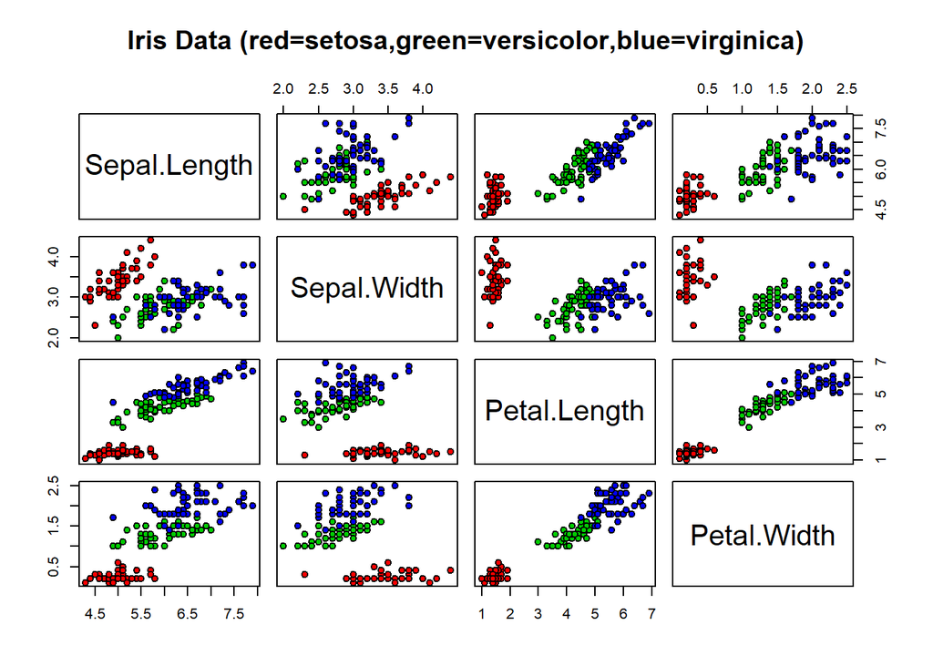

```r
pairs(iris[1:4],main="Iris Data (red=setosa,green=versicolor,blue=virginica)", pch=21,
  bg=c("red","green3","blue")[unclass(iris$Species)])
```

Question 3: Right 2-3 sentences concisely defining the IRIS Data Set. Maybe search KAGGLE for a nice template. Be certain the final writeup are your own sentences (make certain you modify what you find, make it your own, but also cite where you got your ideas from). NOTE: Watch the video, Figure 8 has a +5 EASTER EGG.

The iris data set is a mulitivariate data set that looks at multiple measurments of the iris flower. The data is made up of 50 samples from the species of iris, that being the iris setosa, iris virginca, and iris versicolor. From there the data was able to be obsereved into a linear discriminant model to look at each species independent from one another.

## Cleanup RAW

Question 4 Import “personality-raw.txt” into R. Remove the V00 column. Create two new columns from the current column “date_test”: year and week. Stack Overflow may help: https://stackoverflow.com/questions/22439540/how-to-get-week-numbers-from-dates … Sort the new data frame by YEAR, WEEK so the newest tests are first … The newest tests (e.g., 2020 or 2019) are at the top of the data frame. Then remove duplicates using the unique function based on the column “md5_email”. Save the data frame in the same “pipe-delimited format” ( | is a pipe ) with the headers. You will keep the new data frame as “personality-clean.txt” for future work (you will not upload it at this time). In the homework, for this tasks, report how many records your raw dataset had and how many records your clean dataset has.

838 obs. when uncleaned, now cleaned there are 678 obs.

```r
#reading in the data
data = read.table("C:/personality-raw.txt", sep ="|", header = TRUE, dec = ".")
data
```

[output not shown]

[output cut: 828 more lines]

```r
#removing the V00 column
data$V00 <- NULL
data
```

[output not shown]

[output cut: 828 more lines]

```r
#formating the date
v = as.Date(format(as.POSIXct(data$date_test,format='%m/%d/%Y %H:%M'),format='%m/%d/%Y'),format='%m/%d/%Y')

#creating week and year columns
week = format(as.Date(v), "%W")
year = format(as.Date(v), "%Y")
data$year = year
data$week = week

#removing date_test
data$date_test = NULL

#converting week and year from char to int
converted_year = type.convert(year)
converted_week = type.convert(week)

#ordering the data
data = data[order(data$year, data$week, decreasing = TRUE),]

clean_data = distinct(data, md5_email, .keep_all = TRUE)

#View(data)
dim(data)
```

```
## [1] 838  63
```

```r
dim(clean_data)
```

```
## [1] 678  63
```

```r
write.table(clean_data, "C:/Users/defaultuser0/personality-clean.txt", sep="|")
```